# Guide for Users

Jingwen Yang

2019-05-02

## Pacakge Installation

*AnceTran* is an *R* package that performs analyses of transcriptome evolution based on *RNA-seq* expression data or *ChIP-seq* TF binding data. Here, we use HNF4A-binding data for 4 mice species as an example to show how *AnceTran* works. A convenient way to install package from github is through *devtools* package:

```r
install.packages('devtools')
devtools::install_github("jingwyang/AnceTran")
```

After installation, *AnceTran* can be loaded in the usual way:

```r
library('AnceTran')
```

## Input Format:

*AnceTran* package takes binding score data in certain format:

- Binding score file should be a text file in the matrix shape, `Rows` correspond to orthologous. `Columns` correspond to sample names. Sample names are in format of “`TaxaName_SubtaxaName_ReplicatesName`”.

The example files are included in the AnceTran package, which can be found in `extdata` folder in the package. One can load them in to take a look:

```r
BindingScore.table =read.table(system.file('extdata','HNF4A_meanIntensity_4Mouse.txt',package = 'AnceTran'), header = T)

head(BindingScore.table[,1:5])
```

```
##               GeneID BL6_HNF4A CAST_HNF4A SPRET_HNF4A CAR_HNF4A
## 1 ENSMUSG00000000001  244.6250   338.4167       159.0   96.5000
## 2 ENSMUSG00000000003    0.0000    41.0000         0.0    0.0000
## 3 ENSMUSG00000000028  184.5000   199.6875       289.4  107.0000
## 4 ENSMUSG00000000037    0.0000     0.0000        41.0   20.0000
## 5 ENSMUSG00000000049  224.2632   179.7917       191.5  120.1875
## 6 ENSMUSG00000000056  266.2500   317.0769       141.4  204.8333
```

## Construction:

The construction function `TFconstruct` loads in the BindingScore data file, and wraps them in a list of *taxonTF* objects (one *taxaTF* object).

```r
library('AnceTran')
taxa.objects = tTFConstruct(BSFile=system.file('extdata','HNF4A_meanIntensity_4Mouse.txt',package = 'AnceTran'), taxa="all", tf="all",verbose = TRUE)
```

The construction process takes **several minutes** on a desktop computer depending on data size and hardware performance. Specify **“taxa”** and **“subtaxa”** options in the function when using partial of your data. The construction process will be faster. If you are hesitated to test the *AnceTran*, the package has already bundled a constructed object and you can load the object through:

```r
data(TF.objects)
```

## Data filtering and normalization

We excluded genes whose TF binding score equals to 0 in all species. To account for differences in sequencing depths between species, we quantile-normalized these binding score values across species and also log-transformed the values for the further analysis.

```r
library('limma')
TF_table = TFtab(objects = TF.objects, taxa = "all", tf = "all",rowindex = NULL, filtering = FALSE, normalize = FALSE, logrithm = FALSE)
keep<-rowSums((TF_table == 0)) < ncol(TF_table)
TF_table<-TF_table[keep,]
TF_table<-data.frame(log2(normalizeQuantiles(TF_table[,])+1))
```

## Distance matrix

First, we generate an TF-binding distance matrix of these mice species using *sOU* method:

```r
library('ape')
dismat <- TFdist.sou(bsMat = TF_table)
colnames(dismat)=colnames(TF_table)
rownames(dismat)=colnames(dismat)
dismat
```

```
##             BL6_HNF4A CAST_HNF4A SPRET_HNF4A CAR_HNF4A
## BL6_HNF4A   0.0000000  0.0000000   0.0000000         0
## CAST_HNF4A  0.3588558  0.0000000   0.0000000         0
## SPRET_HNF4A 0.4497102  0.4869901   0.0000000         0
## CAR_HNF4A   0.6862219  0.7693106   0.6649105         0
```

## TF-binding tree building

After the TF-binding distance matrix is created, you can construct character tree by Neighbor-Joining method, and bootstrap values based on re-sampling orthologous genes with replacements can also be generated by `boot.phylo` function:

```r
tf_tree <- NJ(dismat)
tf_tree <- root(tf_tree, outgroup = "CAR_HNF4A", resolve.root = T)
tf_tree <- no0br(tf_tree)

f <- function(xx) {

  mat <- TFdist.sou(t(xx))
  # the distance metrics here should be the same as you specified
  # when you created the TF-binding distance matrix

  colnames(mat) <- rownames(xx)
  rownames(mat) <- colnames(mat)

  root(NJ(mat), "CAR_HNF4A", resolve.root = T)

}
bs <-  boot.phylo(tf_tree, t(TF_table), f, B = 100)
```

```
##
Running bootstraps:       100 / 100
## Calculating bootstrap values... done.
```

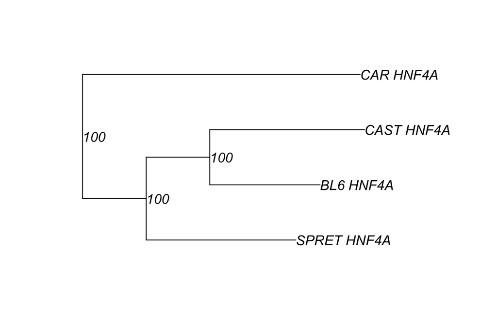

```r
tf_tree$node.label = bs
plot(tf_tree, show.node.label = TRUE)
```

By now, an TF-binding character tree is successfully constructed.

## Creating variance co-variance matrix

```r
var_mat <- varMatInv(dismat,TF_table,phy = tf_tree)
```

## Ancestral TF-binding state estimation

Here, we extract the TF-binding values of gene *MUP20* as an example:

```r
mup20_binding <- TF_table[which(rownames(TF_table) == "ENSMUSG00000078672"),]
```

Then we infer the TF-binding scores at ancestral nodes of the TF-binding tree:

```r
mup20_anc <- aee(mup20_binding, tf_tree, var_mat, select = "all")
```

Finally, we map these estimations on the 4 mice species tree to give a direct presentation of these values:

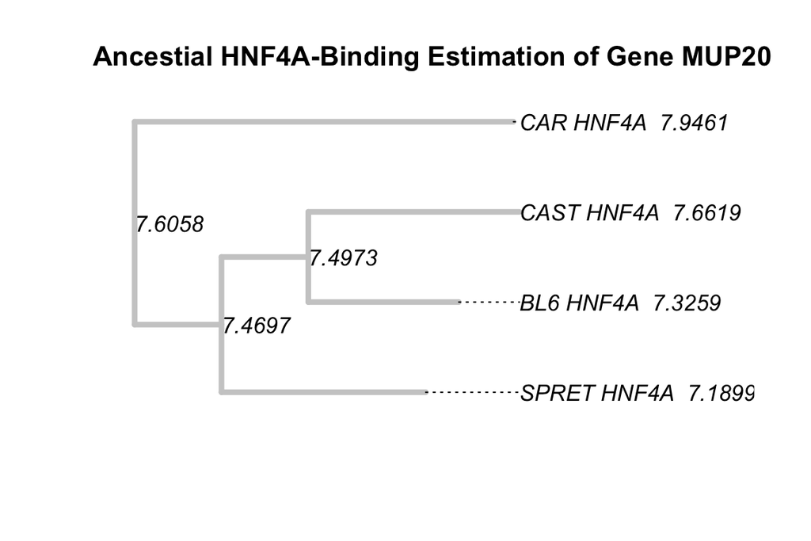

```r
tf_tree$node.label <- sprintf("%.4f",mup20_anc$est)
tf_tree$tip.label <- paste0(tf_tree$tip.label, "  ", sprintf("%.4f", mup20_binding))
plot(tf_tree, edge.color = "grey80", edge.width = 4,show.node.label = T,align.tip.label = T,main="Ancestial HNF4A-Binding Estimation of Gene MUP20")
```